# RNASeq DGE Basics

Yaoyu E. Wang

2020-04-24

# Begin RNA-Seq DGE Analysis

```r
# One can set up the path

load('RNASeq_exploratory.RData')


ls()                       # list all current variables
```

```
## [1] "count_data"          "exploratory_results" "groups"
```

```r
#head(count_data)           # The head(count_data) provides the first 6 row of the 'count_data'
#head(groups)           # The head(count_data) provides the first 6 row of the 'count_data'
```

## Principle component analysis

Once the matrix is loaded, we can perform principle component analysis to visualize sample distribution.  
We first group samples into two vectors/variables: CONTROL and TREATED.

Calculate PCA use ‘prcomp’ command. Since prcomp compute PCA by the rows, we will need to tranpose the count matrix such that the samples are represented by rows and genes by the columns.

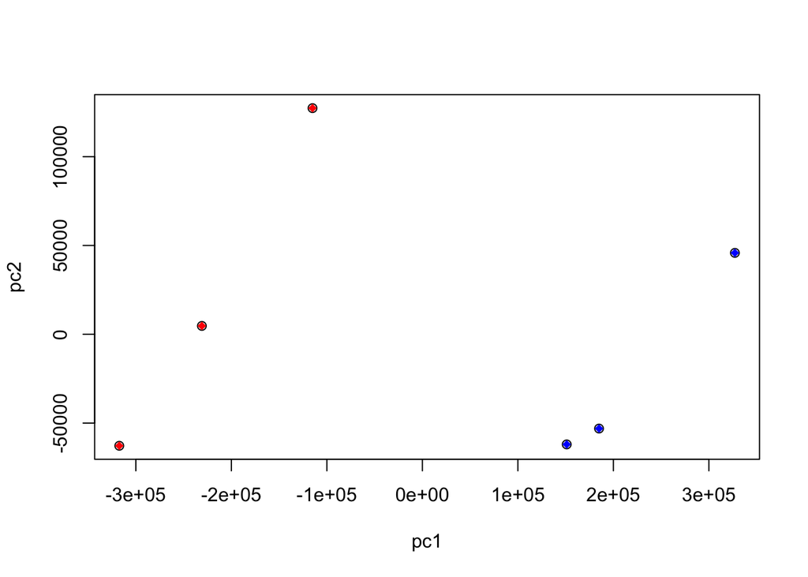

```r
CONTROL=groups$control$sample
TREATED=groups$treated$sample

pca=prcomp(t(count_data))        # compute PCA on transposed count_data
plot(pca$x[,1], pca$x[,2], xlab='pc1', ylab='pc2')
points(pca$x[CONTROL,1], pca$x[CONTROL,2],
       col="red", pch=18)
points(pca$x[TREATED,1], pca$x[TREATED,2],
       col="blue", pch=18)
```

## Hierarchical Clustering

We first calculate similarity matrix using Euclidean distance. The matrix is computed by ‘dist’ function. ‘hclust’ function computes hierarhical cluster tree and save it into an variable object ‘hctree’ that can be ploted by using generic ‘plot’ function.

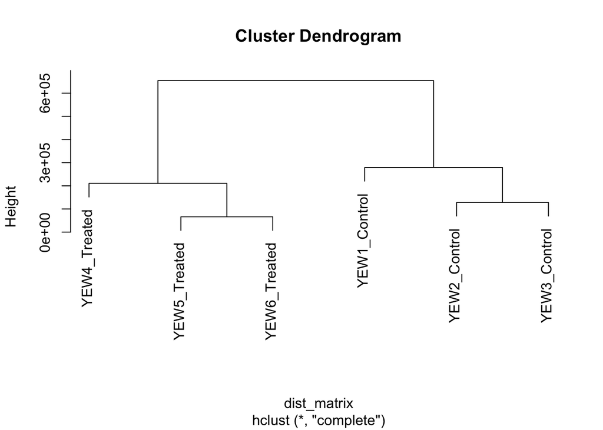

```r
# compute similarity matrix on the transposed count_data matrix using Euclidean distance
dist_matrix=dist(t(count_data), method="euclidean")
# compute hierarchical clustering tree and save it into variable called 'hctree'
hctree=hclust(dist_matrix)
# plot hctree
plot(hctree)
```

## Differential Gene Expression

We will use DESeq2 to perform differential gene expression. Since DESeq2 is a specialized bioconductor package/library, we will need to install it before loading in the package to use.

The following command check if DESeq2 and Bioconductor Manager packages have been installed, and install the packages if they have not been installed.

```r
# Check for Bioconductor, install it if it is not yet installed
  if (!requireNamespace('BiocManager', quietly = TRUE))
    install.packages('BiocManager')

# Check for DESeq2, install it if it is not yet installed
  if(!requireNamespace('DESeq2', quietly = TRUE))
    BiocManager::install('DESeq2', update=FALSE)
```

Once the packages are installed, we can call ‘library’ function to load ‘DESeq2’ library to use its functions.

```r
condition <- factor(c("control", "control", "control",
                      "treated", "treated", "treated"))
# alternatively, since the count_data is ordered in the same way as groups variable
# we can declare condition from groups:
#
# condition <- factor(c(as.character(groups$control$group), as.character(groups$treated$group)))
#
```

If you want to know how to use a specific function in R, just type ‘?function’ in Console. For example type:

> ?DESeqDataSetFromMatrix

```r
# Returns DGE gene list results in data frame format
dge_results=results(dds, contrast=c("condition", "treated", "control"))

# make sure there is no missing values
dge_results=na.omit(dge_results)

# filter for results with padj<0.001 and absolute log2FoldChange>2
filtered_results=subset(dge_results, padj<0.001 & abs(log2FoldChange)>2)

# Obtain normalized count values
norm_count <- counts(dds, normalized = T)

# output filtered_results
filtered_results
```

```
## log2 fold change (MLE): condition treated vs control
## Wald test p-value: condition treated vs control
## DataFrame with 30 rows and 6 columns
##                       baseMean    log2FoldChange             lfcSE
##                      <numeric>         <numeric>         <numeric>
## RP1-137D17.1  29.8839883584897  2.18080051514365 0.525441950834757
## AP000344.4      73.14903147842  2.12391047870749 0.333193245882354
## CTB-134H23.2  16.4631893142531 -4.06989298788851 0.902046395861882
## C12orf40      23.5935805512499 -2.69347617414478 0.622311943521575
## RP11-395P13.1 25.2555673433736  2.25522540567288  0.55251100155043
## ...                        ...               ...               ...
## RP11-413E6.7  62.9678012294187 -3.57669120749119 0.409461162253874
## CTD-2144E22.8 79.2703453044705 -2.48457438278124 0.339133969829025
## RP11-747D18.1  1062.4407047496  2.01064482797773  0.12042205283902
## RP11-864I4.4  25.0810724471142  2.31146493910142  0.55115609828326
## MSMP          44.7309465700437  2.16345289754786 0.400073627551603
##                            stat               pvalue                 padj
##                       <numeric>            <numeric>            <numeric>
## RP1-137D17.1   4.15041188028299 3.31877521851314e-05  0.00026025079086948
## AP000344.4      6.3744103608193 1.83668201976646e-10 3.60334193573427e-09
## CTB-134H23.2  -4.51184440906705 6.42663252483387e-06   5.821921826631e-05
## C12orf40      -4.32817689293055 1.50348695874195e-05  0.00012712159813363
## RP11-395P13.1  4.08177466031332 4.46931192753386e-05 0.000338444791804363
## ...                         ...                  ...                  ...
## RP11-413E6.7  -8.73511711783197 2.43403807314299e-18 1.20260893386853e-16
## CTD-2144E22.8 -7.32623270984574 2.36712611316642e-13 6.83284951698415e-12
## RP11-747D18.1  16.6966496632104 1.38633818987756e-62  7.2031449110832e-60
## RP11-864I4.4   4.19384807008606 2.74261710788168e-05 0.000220325854147882
## MSMP            5.4076368662136 6.38617383047045e-08 8.34139160148505e-07
```

We can compute PCA on normalized matrix again

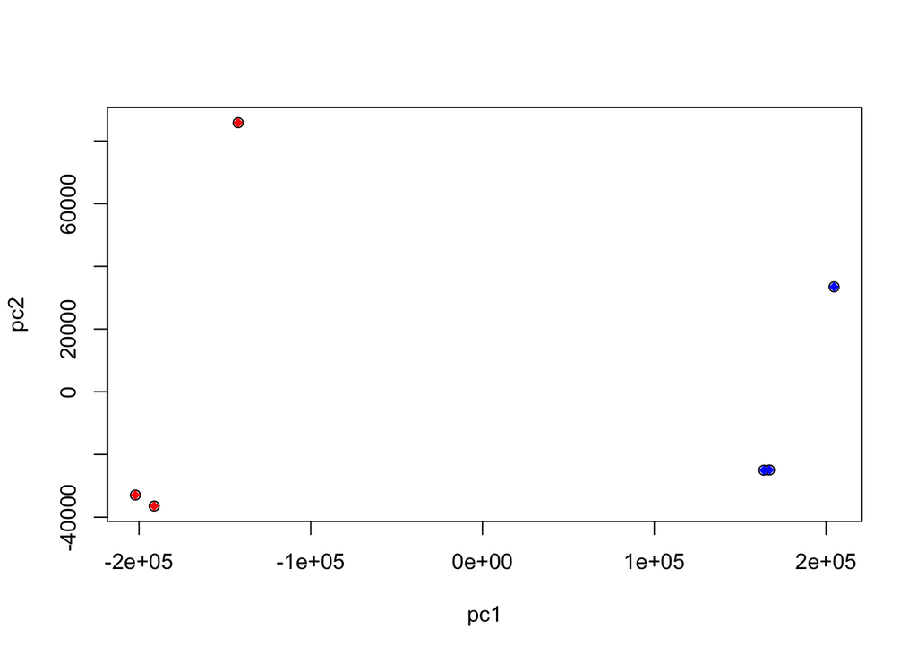

```r
CONTROL=groups$control$sample
TREATED=groups$treated$sample

pca=prcomp(t(norm_count))        # compute PCA on transposed normalized_data
plot(pca$x[,1], pca$x[,2], xlab='pc1', ylab='pc2')
points(pca$x[CONTROL,1], pca$x[CONTROL,2],
       col="red", pch=18)
points(pca$x[TREATED,1], pca$x[TREATED,2],
       col="blue", pch=18)
```

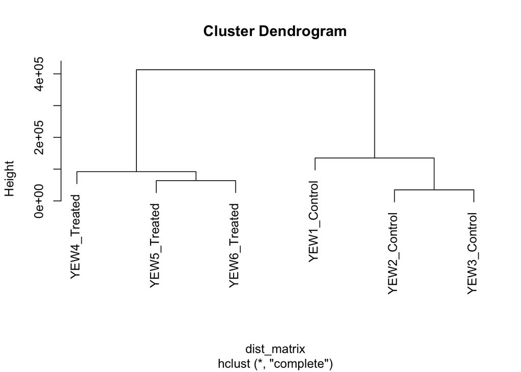

```r
# compute similarity matrix on the transposed count_data matrix using Euclidean distance
dist_matrix=dist(t(norm_count), method="euclidean")
# compute hierarchical clustering tree and save it into variable called 'hctree'
hctree=hclust(dist_matrix)
# plot hctree
plot(hctree)
```

## Heatmap

Generate heatmap using filtered dge results ‘filtered_results’. The heatmap function is core function, but we want to have better coloring, so we install and load gplots.

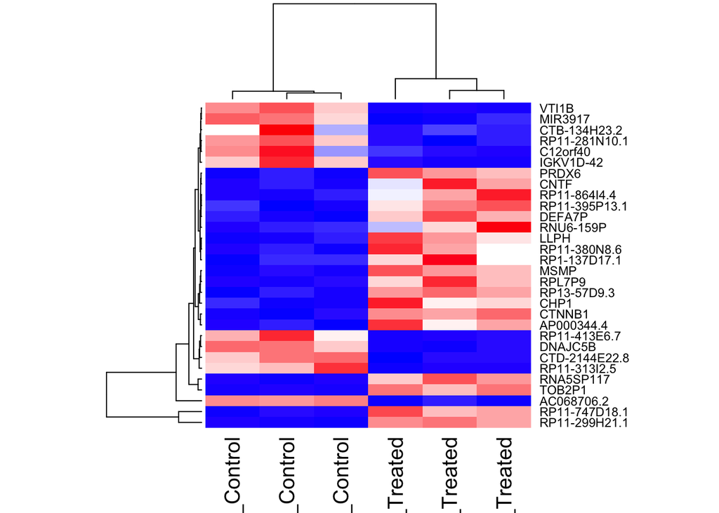

```r
# Check and install "gplots" if not installed
if(!requireNamespace('gplots', quietly = TRUE))
  install.packages('gplots')
library(gplots)
DGE_matrix=norm_count[rownames(filtered_results),]
heatmap(DGE_matrix,col=colorpanel(50, 'blue', 'white', 'red'),
        Rowv=TRUE, Colv=TRUE)
```

```r
# call the commmand again to write it into a file.
png("outputs/heatmap.png")
heatmap(DGE_matrix,col=colorpanel(50, 'blue', 'white', 'red'),
        Rowv=TRUE, Colv=TRUE)
dev.off()
```

## Generate Volcano Plot

Load the library and run EnhancedVolcano function to generate volcano plot.

```r
library(EnhancedVolcano)
```

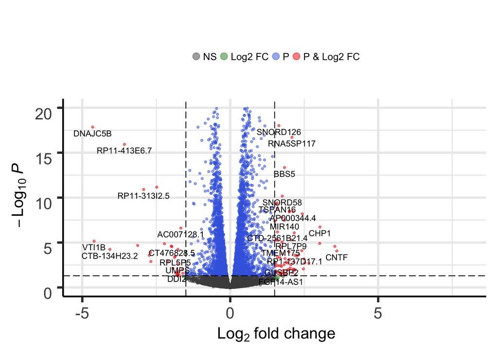

```r
volcano_plot<-EnhancedVolcano(dge_results,
    lab = rownames(dge_results),
    x = 'log2FoldChange',
    y = 'padj',
    xlim = c(-5, 8),
    ylim = c(0, 20),
    #pCutoff = 10e-16,
    FCcutoff = 1.5
)

volcano_plot
```

## Gene Set Erichment Analysis

There are many different packages retreiving MSigDB data to perform GSEA analysis. Most of the packages perform these tasks in very similar ways with different application programming interface (API). We will use the following packages:

- migdbr (https://github.com/igordot/msigdbr)
- fgsea (https://bioconductor.org/packages/release/bioc/html/fgsea.html)

First, we install **misgdbr**

```r
# install misgdbr from CRAN
if(!require(msigdbr)) install.packages("msigdbr")
library(msigdbr)
```

The **misgdbr** retrieve data from MSigDB database hosted at Broad Institute (https://www.gsea-msigdb.org/gsea/msigdb/index.jsp). The function **misgdbr** runs as the following:

```r
m_df = msigdbr(species = "Homo sapiens", category = "C2", subcategory = "CP:KEGG")
# reformat the data frame into list for fgsea input
m_list = m_df %>% split(x = .$gene_symbol, f = .$gs_name)


# install fgsea
if(!require(fgsea)) BiocManager::install("fgsea")
library(fgsea)

# reformat
gene_stat=dge_results$stat
names(gene_stat)=rownames(dge_results)
# sort genes
gene_stat=gene_stat[order(gene_stat)]

fgsea_results=fgsea(pathways=m_list, gene_stat, nperm=50, minSize=20)
fgsea_results=fgsea_results[order(fgsea_results$pval),]
head(fgsea_results)
```

```
##                                       pathway       pval      padj
## 1:   KEGG_ANTIGEN_PROCESSING_AND_PRESENTATION 0.04347826 0.9970674
## 2:                            KEGG_CELL_CYCLE 0.06451613 0.9970674
## 3:              KEGG_ECM_RECEPTOR_INTERACTION 0.06666667 0.9970674
## 4: KEGG_PHOSPHATIDYLINOSITOL_SIGNALING_SYSTEM 0.08695652 0.9970674
## 5:                         KEGG_AXON_GUIDANCE 0.09090909 0.9970674
## 6:          KEGG_SYSTEMIC_LUPUS_ERYTHEMATOSUS 0.09677419 0.9970674
##            ES       NES nMoreExtreme size
## 1: -0.4975169 -1.519065            0   24
## 2:  0.4658802  1.362391            1   37
## 3:  0.4874421  1.387729            1   31
## 4: -0.4796340 -1.470539            1   27
## 5: -0.4746919 -1.452658            1   25
## 6:  0.4383291  1.273090            2   35
##                                    leadingEdge
## 1:      PDIA3,KLRC4,HLA-DOA,RFX5,KIR3DL1,IFNA4
## 2:    CCNB3,SMAD4,RAD21,ZBTB17,MCM2,CDKN1C,...
## 3:      IBSP,HSPG2,ITGA11,COL5A2,VWF,LAMB1,...
## 4: INPP5E,CALML6,CDS1,INPP5A,PLCE1,PIK3C2G,...
## 5:        CDK5,EPHA5,SEMA3E,PPP3R2,EFNA4,UNC5D
## 6:  HIST1H2BK,SSB,C8B,H2AFB3,H2BFM,HIST3H3,...
```

Now write out the GSEA results

```r
library(writexl)    # load  library to write excel file
```

```r
# Current directory is Data directory, change to output
if(!dir.exists('outputs')){
  dir.create('outputs')
}

# using ggplots's ggsave function to save the plot
print("Save the volcano plot in ggplot format")
```

```
## [1] "Save the volcano plot in ggplot format"
```

```r
ggsave("outputs/volcano.png", plot=volcano_plot)
print('Write the final DGE data to Excel file.')
```

```
## [1] "Write the final DGE data to Excel file."
```

```r
# start a new excel file and write final results
write_xlsx(as.data.frame(dge_results), "outputs/dge_results.xlsx", col_names=TRUE)


print('Write the final GSEA data to Excel file.')
```

```
## [1] "Write the final GSEA data to Excel file."
```

```r
# start a new excel file and write final results
write_xlsx(fgsea_results, "outputs/gsea_results.xlsx", col_names=TRUE)
```